# PubMatrixPython — full reference notebook

Complete walkthrough of every parameter and feature. Mirrors the [PubMatrixR documentation](https://toledoem.github.io/pubmatrixr/).

Reference: Becker et al. (2003) BMC Bioinformatics 4:61. https://doi.org/10.1186/1471-2105-4-61

## Overview

**PubMatrixPython** performs systematic literature searches on PubMed and PMC databases using pairwise combinations of search terms. It builds co-occurrence matrices showing the number of publications that mention both terms from two different sets, enabling researchers to explore relationships between genes, diseases, pathways, or any other biomedical concepts.

This is a Python port of the [PubMatrixR](https://toledoem.github.io/pubmatrixr/) R package, with added concurrency, disk caching, and configurable timeouts.

## Key Features

- **Pairwise literature search** — automatically searches all combinations of terms from two lists
- **Multiple database support** — search PubMed or PMC via NCBI E-utilities
- **Heatmap visualisation** — overlap-percentage heatmaps with optional hierarchical clustering
- **Export capabilities** — save results as CSV (with PubMed hyperlink formulas) or ODS
- **Date filtering** — restrict searches to a publication date range
- **Flexible input** — pass term lists directly or load them from a text file
- **Concurrency** — `n_workers` for parallel queries, respecting NCBI rate limits
- **Caching** — `cache_dir` persists query results to disk between runs
- **Progress tracking** — built-in progress bar for long searches

## Use Cases

PubMatrixPython is particularly useful for:

- **Gene–disease association studies** — explore literature connections between genes and diseases
- **Pathway analysis** — investigate co-occurrence of genes within or across biological pathways
- **Drug–target research** — analyse relationships between compounds and potential targets
- **Systematic literature reviews** — quantify research coverage across multiple topics
- **Knowledge gap identification** — find under-researched combinations of terms
- **Bibliometric analysis** — measure research activity in specific domains

## Setup

```python
import sys
sys.path.insert(0, '..')

import pandas as pd
import matplotlib.pyplot as plt

from pubmatrix import (
    pubmatrix,
    pubmatrix_from_file,
    plot_pubmatrix_heatmap,
    pubmatrix_heatmap,
)
```

## NCBI API key

Without a key NCBI allows 3 requests/second; with a key, 10/second. Get one at https://account.ncbi.nlm.nih.gov/

```
API_KEY = "YOUR_KEY_HERE"
```

Leave as `None` to run without one.

```python
API_KEY = None  # replace with your key to increase rate limit
```

## `pubmatrix()` — core query function

```
pubmatrix(
    A,                   # list of str — column terms
    B,                   # list of str — row terms
    api_key   = None,    # NCBI API key
    database  = "pubmed",# "pubmed" or "pmc"
    daterange = None,    # [start_year, end_year]
    outfile   = None,    # base filename for export
    export_format = None,# None | "csv" | "ods"
    n_tries   = 2,       # retries on network failure
    n_workers = 1,       # parallel workers for concurrent queries
    timeout   = 30,      # HTTP request timeout in seconds
    cache_dir = None,    # directory to cache query results on disk
)
```

Returns a `pandas.DataFrame` — rows = B terms, columns = A terms, values = publication counts.

### Basic usage

```python
A = ["WNT1", "WNT2", "CTNNB1"]
B = ["obesity", "diabetes", "cancer"]

result = pubmatrix(A=A, B=B, api_key=API_KEY)
result
```

|  | WNT1 | WNT2 | CTNNB1 |
| --- | --- | --- | --- |
| obesity | 65 | 6 | 93 |
| diabetes | 122 | 18 | 272 |
| cancer | 1286 | 301 | 8451 |

### Larger matrix — 7 × 7 WNT × obesity genes

```python
wnt_genes     = ["WNT1", "WNT2", "WNT3A", "WNT5A", "WNT7B", "CTNNB1", "DVL1"]
obesity_genes = ["LEPR", "ADIPOQ", "PPARG", "TNF", "IL6", "ADRB2", "INSR"]

result_wnt = pubmatrix(A=wnt_genes, B=obesity_genes, api_key=API_KEY)
result_wnt
```

|  | WNT1 | WNT2 | WNT3A | WNT5A | WNT7B | CTNNB1 | DVL1 |
| --- | --- | --- | --- | --- | --- | --- | --- |
| LEPR | 6 | 0 | 0 | 2 | 0 | 4 | 0 |
| ADIPOQ | 2 | 0 | 0 | 6 | 0 | 10 | 0 |
| PPARG | 2 | 3 | 7 | 5 | 1 | 28 | 0 |
| TNF | 83 | 4 | 113 | 126 | 7 | 224 | 3 |
| IL6 | 75 | 7 | 88 | 146 | 10 | 163 | 3 |
| ADRB2 | 1 | 0 | 0 | 2 | 0 | 0 | 0 |
| INSR | 1 | 1 | 1 | 1 | 0 | 4 | 0 |

### `database` parameter

`"pubmed"` (default) searches MEDLINE abstracts. `"pmc"` searches full-text articles in PubMed Central — counts are typically higher.

```python
result_pmc = pubmatrix(A=A, B=B, database="pmc", api_key=API_KEY)
result_pmc
```

|  | WNT1 | WNT2 | CTNNB1 |
| --- | --- | --- | --- |
| obesity | 2828 | 1034 | 5024 |
| diabetes | 4476 | 1643 | 7254 |
| cancer | 12832 | 5183 | 30013 |

```python
# Side-by-side comparison
print("PubMed:")
print(result)
print("\nPMC:")
print(result_pmc)
```

```
PubMed:
          WNT1  WNT2  CTNNB1
obesity     65     6      93
diabetes   122    18     272
cancer    1286   301    8451

PMC:
           WNT1  WNT2  CTNNB1
obesity    2828  1034    5024
diabetes   4476  1643    7254
cancer    12832  5183   30013
```

### `daterange` parameter

Filter results to a publication year range. Useful for tracking how co-occurrence changes over time.

```python
result_2000_2010 = pubmatrix(A=A, B=B, daterange=[2000, 2010], api_key=API_KEY)
result_2011_2024 = pubmatrix(A=A, B=B, daterange=[2011, 2024], api_key=API_KEY)

print("2000–2010:")
print(result_2000_2010)
print("\n2011–2024:")
print(result_2011_2024)
```

```
2000–2010:
          WNT1  WNT2  CTNNB1
obesity      1     0       5
diabetes    11     4      41
cancer     361    82    2100

2011–2024:
          WNT1  WNT2  CTNNB1
obesity     60     6      79
diabetes   103    12     201
cancer     768   169    5349
```

### Output file naming

When `outfile` and `export_format` are specified, the result is written to `{outfile}_result.{extension}` (`.csv` or `.ods`). Each cell contains both the publication count and a hyperlink to the corresponding PubMed search:

- **CSV** — Excel-compatible `HYPERLINK()` formulas
- **ODS** — embedded hyperlinks for LibreOffice/OpenOffice

Row names come from `B`, column names from `A`.

### Export to CSV

Saves a `.csv` where each cell is an Excel `HYPERLINK` formula linking directly to the PubMed search for that term pair.

```python
pubmatrix(A=A, B=B, outfile="output", export_format="csv", api_key=API_KEY)
```

|  | WNT1 | WNT2 | CTNNB1 |
| --- | --- | --- | --- |
| obesity | 65 | 6 | 93 |
| diabetes | 122 | 18 | 272 |
| cancer | 1286 | 301 | 8451 |

### Export to ODS

Same as CSV but in OpenDocument Spreadsheet format, with clickable hyperlinks in LibreOffice / OpenOffice.

`odfpy` is an optional dependency — install with:

```
pip install pubmatrixpython[ods]
```

```python
pubmatrix(A=A, B=B, outfile="output", export_format="ods", api_key=API_KEY)
```

|  | WNT1 | WNT2 | CTNNB1 |
| --- | --- | --- | --- |
| obesity | 65 | 6 | 93 |
| diabetes | 122 | 18 | 272 |
| cancer | 1286 | 301 | 8451 |

### `n_tries` — retry on network failure

Default is 2. Increase for unstable connections.

```python
result_retry = pubmatrix(A=A, B=B, n_tries=5, api_key=API_KEY)
result_retry
```

|  | WNT1 | WNT2 | CTNNB1 |
| --- | --- | --- | --- |
| obesity | 65 | 6 | 93 |
| diabetes | 122 | 18 | 272 |
| cancer | 1286 | 301 | 8451 |

## Concurrency, timeout, and caching

New in v0.2.0: `n_workers` for parallel queries, `timeout` for HTTP requests, and `cache_dir` to persist results on disk between runs.

### `n_workers` — concurrent queries

Set `n_workers > 1` to fetch multiple term pairs in parallel. NCBI rate limits (3 req/s without an API key, 10 req/s with one) are respected automatically.

```python
result_parallel = pubmatrix(A=A, B=B, n_workers=3, n_tries=4, api_key=API_KEY)
result_parallel
```

|  | WNT1 | WNT2 | CTNNB1 |
| --- | --- | --- | --- |
| obesity | 65 | 6 | 93 |
| diabetes | 122 | 18 | 272 |
| cancer | 1286 | 301 | 8451 |

### `timeout` — HTTP request timeout

Default is 30 seconds. Lower it for fast-fail behaviour, or raise it on slow connections.

```python
result_timeout = pubmatrix(A=A, B=B, timeout=10, api_key=API_KEY)
result_timeout
```

|  | WNT1 | WNT2 | CTNNB1 |
| --- | --- | --- | --- |
| obesity | 65 | 6 | 93 |
| diabetes | 122 | 18 | 272 |
| cancer | 1286 | 301 | 8451 |

### `cache_dir` — disk caching

```python
import time

start = time.perf_counter()
result_cached = pubmatrix(A=A, B=B, cache_dir="cache", api_key=API_KEY)
first_run = time.perf_counter() - start

start = time.perf_counter()
result_cached_again = pubmatrix(A=A, B=B, cache_dir="cache", api_key=API_KEY)
second_run = time.perf_counter() - start

print(f"First run (network):  {first_run:.2f}s")
print(f"Second run (cached):  {second_run:.2f}s")
result_cached
```

```
First run (network):  7.22s
Second run (cached):  3.05s
```

|  | WNT1 | WNT2 | CTNNB1 |
| --- | --- | --- | --- |
| obesity | 65 | 6 | 93 |
| diabetes | 122 | 18 | 272 |
| cancer | 1286 | 301 | 8451 |

```python
import shutil

shutil.rmtree("cache", ignore_errors=True)
```

## `pubmatrix_from_file()` — load terms from a text file

File format — A terms first, `#` separator, then B terms:

```
WNT1
WNT2
CTNNB1
#
obesity
diabetes
cancer
```

All keyword arguments are passed through to `pubmatrix()`.

```python
sample_terms = "WNT1\nWNT2\nCTNNB1\n#\nobesity\ndiabetes\ncancer\n"
with open("sample_terms.txt", "w") as f:
    f.write(sample_terms)

result_file = pubmatrix_from_file("sample_terms.txt", api_key=API_KEY)
result_file
```

|  | WNT1 | WNT2 | CTNNB1 |
| --- | --- | --- | --- |
| obesity | 65 | 6 | 93 |
| diabetes | 122 | 18 | 272 |
| cancer | 1286 | 301 | 8451 |

```python
# With optional arguments
result_file_dated = pubmatrix_from_file(
    "sample_terms.txt",
    daterange=[2015, 2024],
    api_key=API_KEY,
)
result_file_dated
```

|  | WNT1 | WNT2 | CTNNB1 |
| --- | --- | --- | --- |
| obesity | 42 | 4 | 68 |
| diabetes | 89 | 11 | 179 |
| cancer | 579 | 136 | 4404 |

```python
import os
os.remove("sample_terms.txt")
```

## Heatmap visualisation

Cell values show **overlap percentage**:

```
overlap = (intersection / union) × 100
union   = row_total + col_total - intersection
```

### `pubmatrix_heatmap()` — quick plot with defaults

```
(<Figure size 1000x800 with 2 Axes>,
 <Axes: title={'center': 'PubMatrix Results'}>)
```

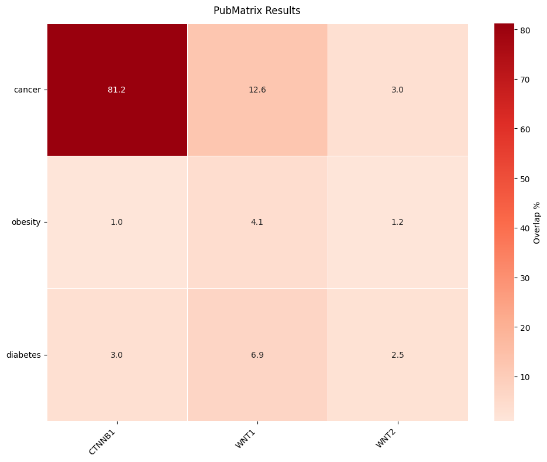

```python
pubmatrix_heatmap(result)
```

### `plot_pubmatrix_heatmap()` — full control

```
plot_pubmatrix_heatmap(
    matrix,
    title          = "PubMatrix Co-occurrence Heatmap",
    cluster_rows   = True,
    cluster_cols   = True,
    show_numbers   = True,
    color_palette  = None,   # list of hex colours; defaults to red gradient
    filename       = None,   # save to PNG if set
    width          = 10,
    height         = 8,
    scale_font     = True,
    show           = False,  # call plt.show() after plotting
)
```

Returns `(fig, ax)` — the figure is not displayed automatically; pass `show=True` or call `plt.show()`/`fig` yourself in interactive sessions.

```
(<Figure size 800x500 with 2 Axes>,
 <Axes: title={'center': 'WNT Genes × Disease Co-occurrence'}>)
```

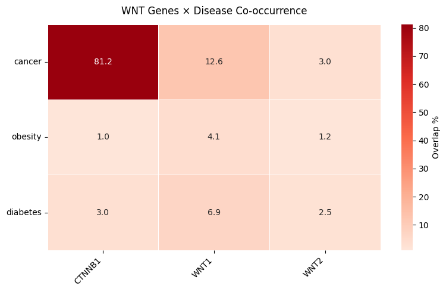

```python
plot_pubmatrix_heatmap(
    result,
    title="WNT Genes × Disease Co-occurrence",
    cluster_rows=True,
    cluster_cols=True,
    show_numbers=True,
    width=8,
    height=5,
)
```

### Clustering disabled

```
(<Figure size 1000x800 with 2 Axes>, <Axes: title={'center': 'No clustering'}>)
```

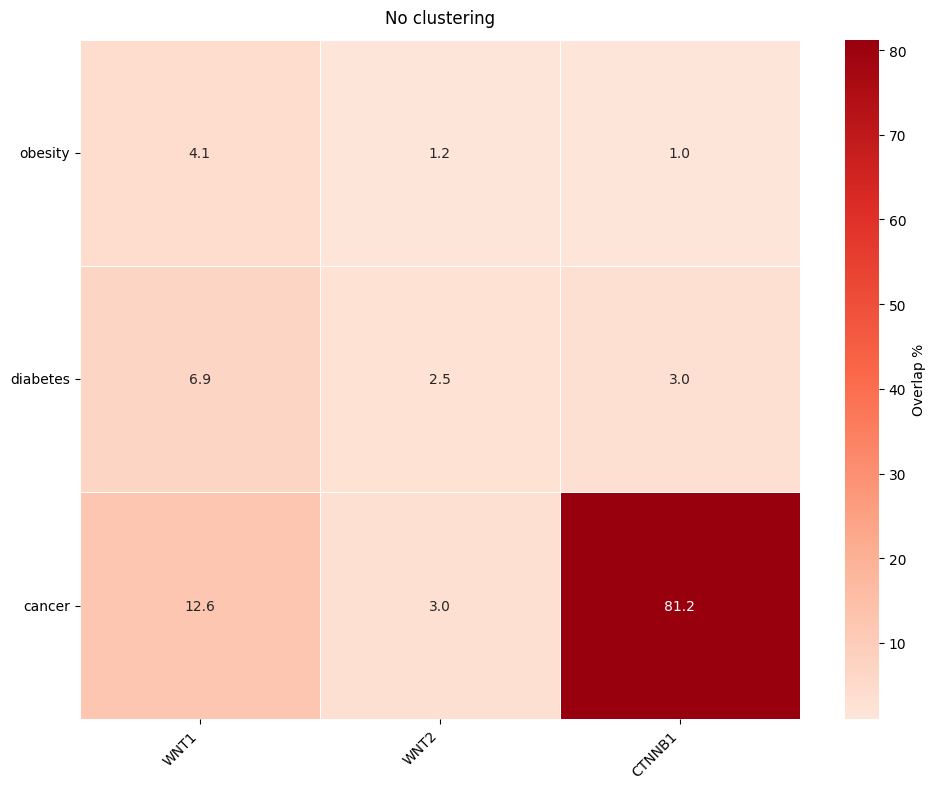

```python
plot_pubmatrix_heatmap(
    result,
    title="No clustering",
    cluster_rows=False,
    cluster_cols=False,
)
```

### Numbers hidden

```
(<Figure size 1000x800 with 2 Axes>,
 <Axes: title={'center': 'No cell annotations'}>)
```

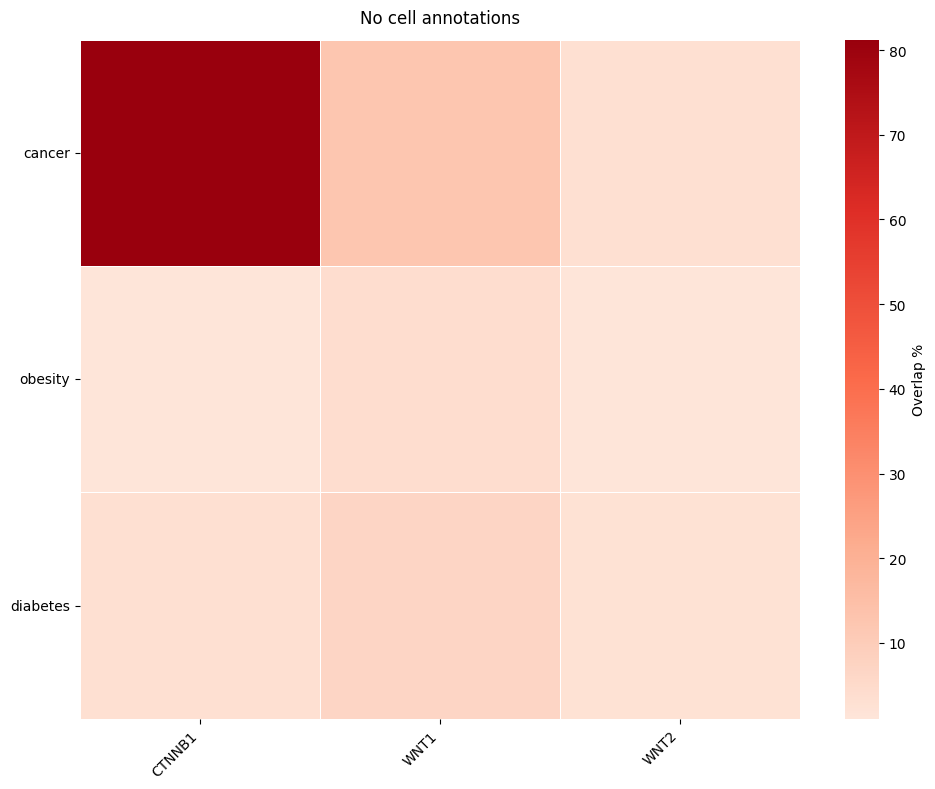

```python
plot_pubmatrix_heatmap(
    result,
    title="No cell annotations",
    show_numbers=False,
)
```

### Custom colour palette

Pass any list of hex colours — gradient is interpolated between them.

```
(<Figure size 1000x800 with 2 Axes>, <Axes: title={'center': 'Blue gradient'}>)
```

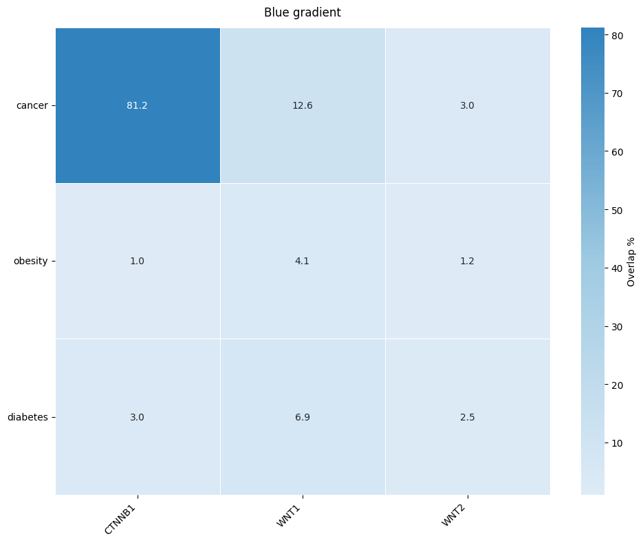

```python
plot_pubmatrix_heatmap(
    result,
    title="Blue gradient",
    color_palette=["#deebf7", "#9ecae1", "#3182bd"],
)
```

```
(<Figure size 1000x800 with 2 Axes>,
 <Axes: title={'center': 'Green gradient'}>)
```

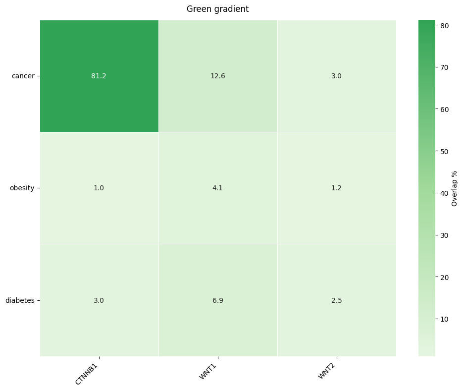

```python
plot_pubmatrix_heatmap(
    result,
    title="Green gradient",
    color_palette=["#e5f5e0", "#a1d99b", "#31a354"],
)
```

### Save to PNG and access `(fig, ax)`

`plot_pubmatrix_heatmap()` returns `(fig, ax)` and no longer calls `plt.show()` automatically. Use `show=True` to display interactively, or work with the returned `Figure`/`Axes` directly.

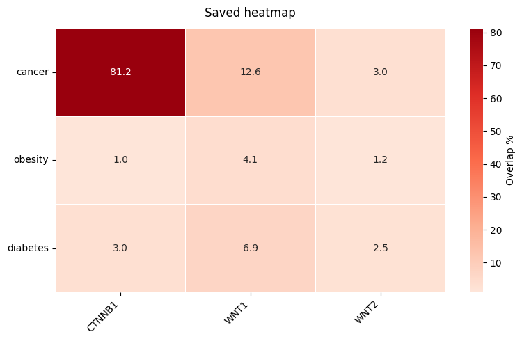

```
<class 'matplotlib.figure.Figure'> <class 'matplotlib.axes._axes.Axes'>
```

```python
fig, ax = plot_pubmatrix_heatmap(
    result,
    title="Saved heatmap",
    filename="heatmap_full.png",
    width=8,
    height=5,
    show=True,
)
print(type(fig), type(ax))
```

## Working with the result DataFrame

The return value is a plain `pandas.DataFrame` — all standard pandas operations apply.

### Summary statistics

```python
print("Column sums (total co-occurrences per A term):")
print(result.sum(axis=0))
print()
print("Row sums (total co-occurrences per B term):")
print(result.sum(axis=1))
```

```
Column sums (total co-occurrences per A term):
WNT1      1473
WNT2       325
CTNNB1    8816
dtype: int64

Row sums (total co-occurrences per B term):
obesity       164
diabetes      412
cancer      10038
dtype: int64
```

### Bar charts — co-occurrences per term

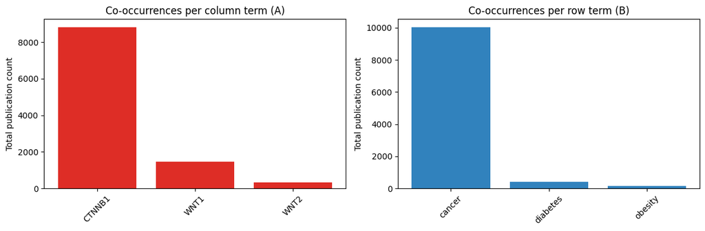

```python
fig, axes = plt.subplots(1, 2, figsize=(12, 4))

col_totals = result.sum(axis=0).sort_values(ascending=False)
axes[0].bar(col_totals.index, col_totals.values, color="#de2d26")
axes[0].set_title("Co-occurrences per column term (A)")
axes[0].set_ylabel("Total publication count")
axes[0].tick_params(axis="x", rotation=45)

row_totals = result.sum(axis=1).sort_values(ascending=False)
axes[1].bar(row_totals.index, row_totals.values, color="#3182bd")
axes[1].set_title("Co-occurrences per row term (B)")
axes[1].set_ylabel("Total publication count")
axes[1].tick_params(axis="x", rotation=45)

plt.tight_layout()
plt.show()
```

### Temporal trend — comparing two date windows

```python
# Reuse results computed above
diff = result_2011_2024 - result_2000_2010
print("Absolute change in co-occurrence counts (2011–2024 vs 2000–2010):")
diff
```

```
Absolute change in co-occurrence counts (2011–2024 vs 2000–2010):
```

|  | WNT1 | WNT2 | CTNNB1 |
| --- | --- | --- | --- |
| obesity | 59 | 6 | 74 |
| diabetes | 92 | 8 | 160 |
| cancer | 407 | 87 | 3249 |

```
(<Figure size 700x400 with 2 Axes>,
 <Axes: title={'center': 'Change in co-occurrences: 2011–2024 vs 2000–2010'}>)
```

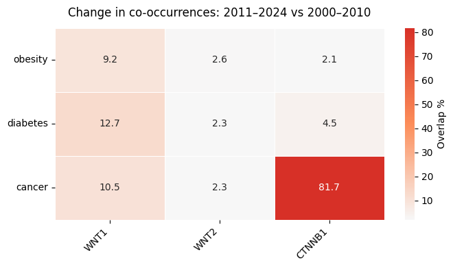

```python
plot_pubmatrix_heatmap(
    diff,
    title="Change in co-occurrences: 2011–2024 vs 2000–2010",
    color_palette=["#f7f7f7", "#fc8d59", "#d73027"],
    cluster_rows=False,
    cluster_cols=False,
    width=7,
    height=4,
)
```

### Save results to CSV manually

```python
result.to_csv("my_results.csv")
print("Saved.")
```

```
Saved.
```

## Performance Notes

- **Rate limiting**: NCBI allows 3 requests/second without an API key, 10/second with one.
- **Search time**: depends on matrix size (A × B combinations), `n_workers`, and network speed.
- **Caching**: set `cache_dir` to avoid re-querying NCBI for identical term pairs across runs.
- **Memory usage**: results are held in memory as a `pandas.DataFrame`; very large matrices may require substantial RAM.

## Troubleshooting

### Empty results

If many searches return 0 results, try:

- Using broader search terms
- Expanding the date range
- Checking spelling of scientific terms
- Using alternative gene names or synonyms

### Rate limiting errors (HTTP 429)

If you encounter `RuntimeError` from repeated 429 responses:

- Obtain and use an NCBI API key (`api_key=...`)
- Reduce `n_workers` or the size of your search matrix
- Increase `n_tries` to allow more retries with backoff

### Long search times

For large matrices:

- Consider breaking into smaller sub-searches
- Use more specific date ranges
- Use `cache_dir` so repeated runs skip already-fetched pairs
- Increase `n_workers` (while respecting rate limits)

## License & Citation

This project is licensed under the MIT License — see `LICENSE.md` for details.

If you use PubMatrixPython in your research, please cite:

> Becker KG, Hosack DA, Dennis G Jr, Lempicki RA, Bright TJ, Cheadle C, Engel J. *PubMatrix: a tool for multiplex literature mining.* BMC Bioinformatics. 2003 Dec 10;4:61. https://doi.org/10.1186/1471-2105-4-61

**Developers:**

- Tyler Laird (Author, original PubMatrixR)
- Enrique Toledo (Author, maintainer)